# LEGO as an investment: does the 2015 evidence predict out of sample?

Hiro, Hendrik, Stefan

13 October 2026

# 0. Research question and data

Dobrynskaya and Kishilova (2022, *LEGO: The Toy of Smart Investors*, RIBF) find that retired LEGO sets earned about 11% a year on the secondary market between 1987 and 2015 and that the return of a set depends on its theme, size and year of release (Table 5 of the paper, R² = 0.47). Their regression is estimated and evaluated on the same 2,300 sets, so it says which sets *did* appreciate, not which sets *will*. We ask two questions with the authors’ own published data (Mendeley Data v9hhs66vm3):

1. **Experiment 1, cross-sectional generalisation: do set characteristics generalise to sets a model has never seen?** Five-fold cross-validation by set: every model is estimated on 80% of the sets and evaluated on the other 20%. This tests generalisation across sets, not through time.
2. **Experiment 2, forward-return predictability: did the LEGO premium persist after 2015, and is the forward return predictable?** The authors’ second file gives monthly prices from January 2018 to April 2019 for the same sets, so we can compute the return an investor earned after December 2015 and test what information available in 2015 predicts it. This is the test of predictive ability through time.

We compare the models of the course: OLS, ridge, LASSO, elastic net, a regression tree, a random forest and XGBoost, scored by out-of-sample R², RMSE, rank correlation and hit ratios.

```r
library(tidyverse)
library(readxl)
library(glmnet)
library(rpart)
library(rpart.plot)
library(randomForest)
library(knitr)
has_xgb <- requireNamespace("xgboost", quietly = TRUE)       # XGBoost is optional: the file runs without it
if (has_xgb) library(xgboost)

data_dir <- "."                                               # The four DiB Excel files sit next to this Rmd

# 2015 cross-section: one row per set, as in the paper
raw_2015 <- read_excel(file.path(data_dir, "DiB whole sample Dec 2015 prices.xlsx"),
                       sheet = "DATA", na = c("", "NA", "ND"))
names(raw_2015) <- c("id", "theme", "name", "year", "pieces", "minifigs",
                     "p_new_2015", "p_used_2015", "p_retail", "age", "size")
sets <- raw_2015 %>%
  mutate(across(c(minifigs, p_new_2015, p_used_2015), as.numeric),
         id = as.character(id),
         theme = relevel(factor(theme), ref = "Miscellaneous"),  # Same reference theme as the paper
         size = factor(size, levels = 1:4),                      # Size group: 1 = biggest, 4 = smallest
         year_f = factor(year),
         log_retail = log(p_retail)) %>%
  filter(p_new_2015 > 0, p_retail > 0, !is.na(minifigs)) %>%     # A price of 0 means "no sale"
  droplevels() %>%
  mutate(y15 = log(p_new_2015 / p_retail) / (2015 - year),       # Annualised log return since release, to Dec 2015
         prem15 = log(p_new_2015 / p_retail),                     # Cumulative premium over retail in Dec 2015
         log_p15 = log(p_new_2015))                               # Price level in Dec 2015

# Monthly secondary-market prices, January 2018 to April 2019, same sets
raw_1819 <- read_excel(file.path(data_dir, "DiB whole sample Jan 2018 - Apr 2019 prices.xlsx"),
                       skip = 1, na = c("", "NA", "ND"))         # Row 1 is a title
month_cols <- names(raw_1819)[-(1:6)]                            # Month headers are Excel serial numbers
names(raw_1819)[-(1:6)] <- as.character(as.Date(as.numeric(month_cols), origin = "1899-12-30"))
prices_1819 <- raw_1819 %>%
  mutate(id = as.character(id)) %>%
  select(id, matches("^20")) %>%                                 # id and the 16 month columns
  pivot_longer(-id, names_to = "date", values_to = "p") %>%      # Long: one row per set x month
  mutate(date = as.Date(date)) %>%
  filter(!is.na(p), p > 0)

# Forward returns: Dec 2015 -> last observed price (Apr 2019 for 99% of sets), and Jan 2018 -> last price
p_end <- prices_1819 %>% group_by(id) %>% slice_max(date, n = 1, with_ties = FALSE) %>% ungroup() %>%
  transmute(id, date_end = date, p_end = p)
p_jan18 <- prices_1819 %>% filter(date == as.Date("2018-01-01")) %>% transmute(id, p_jan18 = p)
sets <- sets %>%
  left_join(p_end, by = "id") %>%
  left_join(p_jan18, by = "id") %>%
  mutate(h  = as.numeric(date_end - as.Date("2015-12-01")) / 365.25,   # Years held from Dec 2015
         h2 = as.numeric(date_end - as.Date("2018-01-01")) / 365.25,   # Years held from Jan 2018
         y_fwd  = log(p_end / p_new_2015) / h,                         # Forward return 2015 -> 2019, log p.a.
         y_fwd2 = ifelse(h2 > 0.5, log(p_end / p_jan18) / h2, NA))     # Forward return 2018 -> 2019 ("clean window")

# For the ML models: pool rare themes and early years, so every level has enough sets to learn from.
# This uses only the COUNT of sets per level, never a return, so it is a fixed preprocessing rule, not a leak
sets <- sets %>%
  mutate(theme_ml = fct_lump_min(theme, min = 15, other_level = "Other"),
         year_ml  = factor(ifelse(year < 1995, "pre-1995", as.character(year))),
         pieces_sq = pieces^2)

# Small helpers for the text
f3  <- function(x) formatC(x, format = "f", digits = 3)
pct <- function(x) paste0(formatC(100 * x, format = "f", digits = 1), "%")
```

The sample: 2,300 retired sets with a retail price and a December 2015 secondary-market price

| Variable | Sets | Mean | Median | SD | Share > 0 |
| --- | --- | --- | --- | --- | --- |
| Return since release to Dec 2015 (y15, log, p.a.) | 2300 | 0.148 | 0.114 | 0.186 | 0.904 |
| Premium over retail in Dec 2015 (prem15, log) | 2300 | 0.747 | 0.675 | 0.632 | 0.904 |
| Forward return Dec 2015 to Apr 2019 (y_fwd, log, p.a.) | 2271 | -0.029 | -0.017 | 0.153 | 0.439 |
| Forward return Jan 2018 to Apr 2019 (y_fwd2, log, p.a.) | 2205 | -0.036 | -0.023 | 0.195 | 0.425 |

**Answer.** The sample is the paper’s: 2300 retired sets released between 1981 and 2014. Up to December 2015 the average set earned 14.8% a year in log terms and 90.4% of sets were above their retail price. After 2015 the picture reverses: from December 2015 to April 2019 the average set lost 2.9% a year and only 43.9% of sets gained.

# 1. Replication of the paper’s regression (Table 5)

```r
fit_paper <- lm(log(p_new_2015 / p_retail) ~ theme + size + year_f,   # Paper: cumulative log return
                data = sets)                                           # on theme, size and year dummies
```

Replication of Table 5

| Coefficient | Our estimate | Paper, Table 5 |
| --- | --- | --- |
| Batman theme | 0.4501 | 0.4484 |
| Discovery theme | 0.6145 | 0.6124 |
| Size group 2 (vs 1) | -0.2268 | -0.2438 |
| R squared | 0.4701 | 0.4695 |

# 2. Experiment 1: cross-sectional generalisation (unseen sets)

```r
# Design matrices are built once on the full sample, so the dummy columns are identical in every fold
f_paper <- ~ theme_ml + size + year_ml
f_full  <- ~ theme_ml + size + year_ml + pieces + pieces_sq + minifigs + log_retail
f_mom   <- ~ theme_ml + size + year_ml + pieces + pieces_sq + minifigs + log_retail + prem15 + log_p15 + y15
rhs_full <- c("theme_ml", "size", "year_ml", "pieces", "minifigs", "log_retail")   # For the tree models
rhs_mom  <- c(rhs_full, "prem15", "log_p15", "y15")

# One function: fit a model on the training fold and predict the test fold
fit_predict <- function(model, X_tr, y_tr, X_te, df_tr, df_te, rhs, seed = 42){
  set.seed(seed)                                                        # Same seed for every model
  switch(model,
    "Naive (mean)"  = rep(mean(y_tr), nrow(X_te)),                      # Always the training mean
    "OLS"           = { b <- coef(lm.fit(cbind(1, X_tr), y_tr))         # Plain least squares
                        b[is.na(b)] <- 0                                # Aliased columns: weight 0
                        as.numeric(cbind(1, X_te) %*% b) },
    "Ridge"         = as.numeric(predict(cv.glmnet(X_tr, y_tr, alpha = 0),   X_te, s = "lambda.min")),
    "LASSO"         = as.numeric(predict(cv.glmnet(X_tr, y_tr, alpha = 1),   X_te, s = "lambda.min")),
    "Elastic net"   = as.numeric(predict(cv.glmnet(X_tr, y_tr, alpha = 0.5), X_te, s = "lambda.min")),   # Lambda by CV in the fold
    "Tree"          = predict(rpart(reformulate(rhs, "y"), data = df_tr,
                                    minbucket = 30, cp = 0.001, maxdepth = 4, xval = 0), df_te),
    "Random forest" = predict(randomForest(reformulate(rhs, "y"), data = df_tr,
                                           ntree = 300, mtry = max(2, floor(length(rhs) / 3)),   # 1/3 of features per split
                                           nodesize = 10, sampsize = floor(0.7 * nrow(df_tr)), replace = FALSE), df_te),
    "XGBoost"       = { if (!has_xgb) return(rep(NA_real_, nrow(X_te)))
                        fit <- xgb.train(params = list(objective = "reg:squarederror", eta = 0.05, max_depth = 3,
                                                       subsample = 0.8, colsample_bytree = 0.8, lambda = 1, nthread = 2),
                                         data = xgb.DMatrix(X_tr, label = y_tr), nrounds = 300, verbose = 0)
                        predict(fit, X_te) })
}

# Out-of-fold predictions for one target and one feature set, all models
cv_models <- function(df, target, formula_x, rhs, k = 5, seed = 42,
                      models = c("Naive (mean)", "OLS", "Ridge", "LASSO", "Elastic net", "Tree", "Random forest", "XGBoost")){
  df <- df %>% filter(!is.na(.data[[target]])) %>% mutate(y = .data[[target]])
  X <- model.matrix(formula_x, data = df)[, -1, drop = FALSE]         # Dummies; drop the intercept
  set.seed(seed)
  fold <- sample(rep(1:k, length.out = nrow(df)))                     # Random folds BY SET, fixed seed
  lapply(models, function(m){
    pred <- rep(NA_real_, nrow(df))
    for (f in 1:k) {
      tr <- fold != f                                                 # Train on 4 folds ...
      pred[!tr] <- fit_predict(m, X[tr, , drop = FALSE], df$y[tr],    # ... and predict the 5th
                               X[!tr, , drop = FALSE], df[tr, ], df[!tr, ], rhs, seed = seed + f)
    }
    tibble(Model = m, id = df$id, y = df$y, pred = pred)
  }) %>% bind_rows() %>% filter(!is.na(pred))
}

# Scores on the out-of-fold predictions
score <- function(oof){
  oof %>% group_by(Model) %>%
    summarise(`OOS R2`     = 1 - mean((y - pred)^2) / mean((y - mean(y))^2),   # Out-of-sample R squared
              RMSE         = sqrt(mean((y - pred)^2)),
              `Rank corr.` = if (sd(pred) == 0) NA else cor(pred, y, method = "spearman"),
              `Median hit` = if (sd(pred) == 0) NA else mean((pred > median(pred)) == (y > median(y))),
              `Sign hit`   = mean(pred * y > 0),                       # Book's hit ratio: same sign?
              .groups = "drop") %>%
    arrange(RMSE)
}
```

```r
oof_paper <- cv_models(sets, "y15", f_paper, c("theme_ml", "size", "year_ml"), models = c("Naive (mean)", "OLS"))
oof_full  <- cv_models(sets, "y15", f_full, rhs_full)

r2_in <- c(paper = summary(lm(y15 ~ theme_ml + size + year_ml, sets))$r.squared,   # In-sample, for comparison
           full  = summary(lm(y15 ~ theme_ml + size + year_ml + pieces + pieces_sq + minifigs + log_retail, sets))$r.squared)

res2 <- bind_rows(score(oof_paper) %>% mutate(Features = "Paper (theme, size, year)"),
                  score(oof_full)  %>% mutate(Features = "Paper + pieces, minifigures, retail price")) %>%
  select(Features, everything())
```

Held-out sets (5-fold CV by set). Target: annualised return since release to Dec 2015

| Features | Model | OOS R2 | RMSE | Rank corr. | Median hit | Sign hit |
| --- | --- | --- | --- | --- | --- | --- |
| Paper (theme, size, year) | OLS | 0.226 | 0.164 | 0.456 | 0.678 | 0.880 |
| Paper (theme, size, year) | Naive (mean) | -0.001 | 0.186 | -0.006 | 0.504 | 0.904 |
| Paper + pieces, minifigures, retail price | XGBoost | 0.486 | 0.133 | 0.596 | 0.710 | 0.911 |
| Paper + pieces, minifigures, retail price | Random forest | 0.486 | 0.133 | 0.640 | 0.735 | 0.914 |
| Paper + pieces, minifigures, retail price | Tree | 0.364 | 0.148 | 0.484 | 0.646 | 0.913 |
| Paper + pieces, minifigures, retail price | LASSO | 0.297 | 0.156 | 0.523 | 0.681 | 0.871 |
| Paper + pieces, minifigures, retail price | Elastic net | 0.297 | 0.156 | 0.523 | 0.683 | 0.872 |
| Paper + pieces, minifigures, retail price | Ridge | 0.296 | 0.156 | 0.528 | 0.689 | 0.869 |
| Paper + pieces, minifigures, retail price | OLS | 0.293 | 0.156 | 0.529 | 0.688 | 0.862 |
| Paper + pieces, minifigures, retail price | Naive (mean) | -0.001 | 0.186 | -0.006 | 0.504 | 0.904 |

**Answer.** Our target is the *annualised* return, so the R² values are lower than the paper’s 0.47, which is for the cumulative return where the year dummies also absorb the holding period (in sample: 26.0% for the paper’s features, 33.1% with the extra features). On held-out sets the OLS with the paper’s features keeps an out-of-sample R² of 0.226, so most of the explanatory power generalises: theme and year of release really do separate sets that appreciated from sets that did not. Adding pieces, minifigures and the retail price raises the out-of-sample R² of OLS to 0.293. The best model is the **XGBoost** with an out-of-sample R² of 0.486 and a rank correlation of 0.596; the rank correlations of the other models lie between 0.484 and 0.640. The penalised regressions add little over OLS because the sample is large relative to the number of dummies, while the tree models gain from interactions between theme, size and age. (The penalised models choose their penalty by cross-validation inside each training fold; the tree, random forest and XGBoost use fixed settings from the course, so the model comparison is indicative, not a tuned contest.) The answer to Experiment 1 is yes: the paper’s result is not an artefact of in-sample fitting.

# 3. Experiment 2: forward-return predictability, 2015 to 2019

```r
oof_f_char <- cv_models(sets, "y_fwd", f_full, rhs_full)                  # Characteristics only
oof_f_mom  <- cv_models(sets, "y_fwd", f_mom,  rhs_mom)                   # + 2015 price, premium, return
oof_f_y15  <- cv_models(sets, "y_fwd", ~ y15, "y15", models = c("OLS"))   # The 2015 return alone

res3 <- bind_rows(score(oof_f_char) %>% mutate(Features = "Characteristics"),
                  score(oof_f_mom)  %>% mutate(Features = "Characteristics + 2015 price, premium, return"),
                  score(oof_f_y15)  %>% mutate(Features = "2015 return only")) %>%
  select(Features, everything())
```

Held-out sets. Target: forward return December 2015 to April 2019 (log, p.a.)

| Features | Model | OOS R2 | RMSE | Rank corr. | Median hit | Sign hit |
| --- | --- | --- | --- | --- | --- | --- |
| Characteristics | Random forest | 0.210 | 0.136 | 0.507 | 0.692 | 0.690 |
| Characteristics | XGBoost | 0.202 | 0.136 | 0.496 | 0.684 | 0.666 |
| Characteristics | Ridge | 0.179 | 0.138 | 0.434 | 0.665 | 0.640 |
| Characteristics | LASSO | 0.178 | 0.139 | 0.432 | 0.662 | 0.642 |
| Characteristics | Elastic net | 0.178 | 0.139 | 0.432 | 0.664 | 0.641 |
| Characteristics | OLS | 0.173 | 0.139 | 0.431 | 0.663 | 0.642 |
| Characteristics | Tree | 0.137 | 0.142 | 0.390 | 0.627 | 0.621 |
| Characteristics | Naive (mean) | 0.000 | 0.153 | -0.015 | 0.486 | 0.559 |
| Characteristics + 2015 price, premium, return | Random forest | 0.396 | 0.119 | 0.659 | 0.744 | 0.738 |
| Characteristics + 2015 price, premium, return | XGBoost | 0.386 | 0.120 | 0.644 | 0.731 | 0.732 |
| Characteristics + 2015 price, premium, return | LASSO | 0.372 | 0.121 | 0.615 | 0.725 | 0.717 |
| Characteristics + 2015 price, premium, return | Elastic net | 0.372 | 0.121 | 0.614 | 0.727 | 0.715 |
| Characteristics + 2015 price, premium, return | Ridge | 0.371 | 0.121 | 0.614 | 0.723 | 0.717 |
| Characteristics + 2015 price, premium, return | OLS | 0.365 | 0.122 | 0.612 | 0.723 | 0.712 |
| Characteristics + 2015 price, premium, return | Tree | 0.270 | 0.130 | 0.542 | 0.694 | 0.690 |
| Characteristics + 2015 price, premium, return | Naive (mean) | 0.000 | 0.153 | -0.015 | 0.486 | 0.559 |
| 2015 return only | OLS | 0.023 | 0.151 | 0.267 | 0.594 | 0.580 |

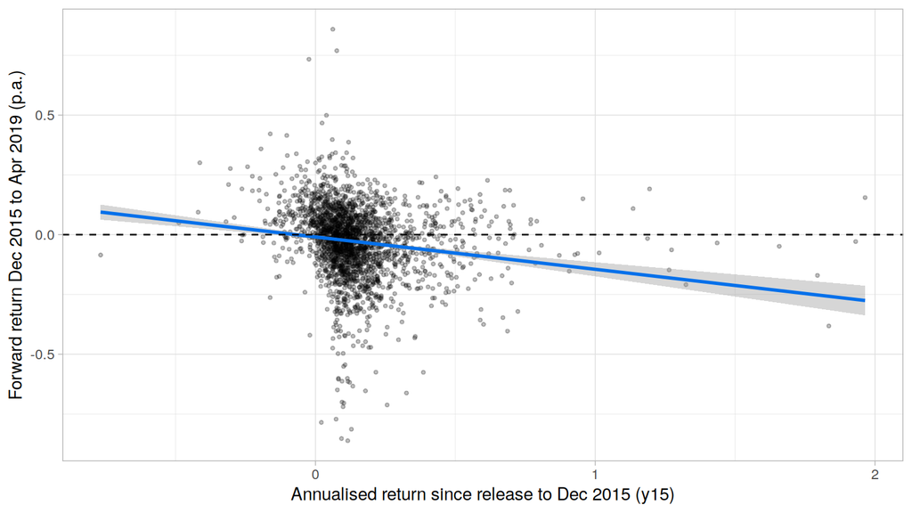

Past winners became losers: return since release to 2015 against the forward return 2015 to 2019

```r
sets %>% filter(!is.na(y_fwd)) %>%
  ggplot(aes(x = y15, y = y_fwd)) +
  geom_point(alpha = 0.25, size = 0.8) +
  geom_smooth(method = "lm", colour = "#0570EA") +
  geom_hline(yintercept = 0, linetype = 2) +
  labs(x = "Annualised return since release to Dec 2015 (y15)", y = "Forward return Dec 2015 to Apr 2019 (p.a.)") +
  theme_light()
```

**Answer.** The LEGO premium did not continue: between December 2015 and April 2019 the average set lost 2.9% a year and 56.1% of sets fell in price. Characteristics still carry some information about the forward return (out-of-sample R² up to 0.210, mostly through the year of release), but the strongest predictors are the ones the paper does not use as predictors: the December 2015 price level and the return already earned, both with a *negative* sign. The correlation between the 2015 return and the 2015-2019 return is -0.162: the sets that had appreciated most did worst afterwards. With these features the best model reaches an out-of-sample R² of 0.396. Part of this is mechanical: a too-high December 2015 price quote raises the 2015 return and lowers the measured forward return at the same time, so the next section repeats the test on a window that does not contain the 2015 price.

# 4. Experiment 2, clean window: return 2018 to 2019 with 2015 information

```r
oof_c_char <- cv_models(sets, "y_fwd2", f_full, rhs_full)                 # Same features, target: Jan 2018 -> Apr 2019
oof_c_mom  <- cv_models(sets, "y_fwd2", f_mom,  rhs_mom)

res4 <- bind_rows(score(oof_c_char) %>% mutate(Features = "Characteristics"),
                  score(oof_c_mom)  %>% mutate(Features = "Characteristics + 2015 price, premium, return")) %>%
  select(Features, everything())
best4 <- res4 %>% filter(Model != "Naive (mean)") %>% slice_min(RMSE, n = 1)   # Best model, clean window
```

Held-out sets. Target: forward return January 2018 to April 2019, features as of December 2015

| Features | Model | OOS R2 | RMSE | Rank corr. | Median hit | Sign hit |
| --- | --- | --- | --- | --- | --- | --- |
| Characteristics | LASSO | 0.075 | 0.187 | 0.306 | 0.620 | 0.608 |
| Characteristics | Elastic net | 0.075 | 0.187 | 0.306 | 0.620 | 0.607 |
| Characteristics | Ridge | 0.074 | 0.188 | 0.303 | 0.618 | 0.609 |
| Characteristics | Random forest | 0.064 | 0.189 | 0.306 | 0.618 | 0.611 |
| Characteristics | OLS | 0.064 | 0.189 | 0.302 | 0.623 | 0.608 |
| Characteristics | XGBoost | 0.058 | 0.189 | 0.296 | 0.609 | 0.608 |
| Characteristics | Tree | 0.042 | 0.191 | 0.273 | 0.596 | 0.610 |
| Characteristics | Naive (mean) | -0.001 | 0.195 | -0.032 | 0.495 | 0.560 |
| Characteristics + 2015 price, premium, return | Elastic net | 0.102 | 0.185 | 0.349 | 0.629 | 0.615 |
| Characteristics + 2015 price, premium, return | LASSO | 0.102 | 0.185 | 0.349 | 0.627 | 0.615 |
| Characteristics + 2015 price, premium, return | Ridge | 0.101 | 0.185 | 0.350 | 0.629 | 0.618 |
| Characteristics + 2015 price, premium, return | Random forest | 0.097 | 0.185 | 0.346 | 0.613 | 0.629 |
| Characteristics + 2015 price, premium, return | OLS | 0.092 | 0.186 | 0.346 | 0.624 | 0.624 |
| Characteristics + 2015 price, premium, return | XGBoost | 0.078 | 0.187 | 0.315 | 0.605 | 0.592 |
| Characteristics + 2015 price, premium, return | Tree | 0.034 | 0.192 | 0.268 | 0.587 | 0.595 |
| Characteristics + 2015 price, premium, return | Naive (mean) | -0.001 | 0.195 | -0.032 | 0.495 | 0.560 |

**Answer.** The reversal is still there in the clean window. Predicting the January 2018 to April 2019 return with December 2015 information only, the rank correlation is 0.350 with the price-history features against 0.306 with characteristics alone, and the best model, **Elastic net**, reaches an out-of-sample R² of 0.102. The numbers are much smaller than in Section 3, which confirms that part of the 2015-2019 result was the mechanical effect of the 2015 price. In this window a noisy 2015 price enters only the predictors, not the target, and such noise weakens a relationship towards zero rather than creating a negative one, so the mechanical channel is closed here. The result therefore *supports* mean reversion in LEGO prices but does not prove it: other explanations remain, such as fashions in particular themes, re-releases of popular sets by LEGO, or the composition of the authors’ sample. Across models the differences are small: the penalised regressions, OLS and the random forest are within 0.007 of each other in RMSE.

# 5. Investor view: sorting sets on the forecast

```r
oof_best <- (if (grepl("2015 price", best4$Features)) oof_c_mom else oof_c_char) %>%
  filter(Model == best4$Model)                                            # Held-out forecasts of the best model
sorts <- oof_best %>%
  mutate(Quintile = ntile(pred, 5)) %>%                                   # 1 = lowest forecast, 5 = highest
  group_by(Quintile) %>%
  summarise(Sets = n(),
            `Mean forecast` = mean(pred),
            `Realised return (p.a.)` = mean(y),
            `Share positive` = mean(y > 0), .groups = "drop")
spread <- sorts$`Realised return (p.a.)`[5] - sorts$`Realised return (p.a.)`[1]
tt <- t.test(oof_best$y[ntile(oof_best$pred, 5) == 5],
             oof_best$y[ntile(oof_best$pred, 5) == 1])                  # Top vs bottom quintile, sets independent

# Sets of the same theme move together, so also a t-statistic with standard errors clustered by theme
library(sandwich)
tb <- oof_best %>% mutate(Quintile = ntile(pred, 5)) %>% filter(Quintile %in% c(1, 5)) %>%
  left_join(sets %>% select(id, theme), by = "id") %>% mutate(top = Quintile == 5)
fit_tb <- lm(y ~ top, data = tb)                                          # Coefficient on top = the spread
t_cluster <- coef(fit_tb)["topTRUE"] / sqrt(vcovCL(fit_tb, cluster = tb$theme)["topTRUE", "topTRUE"])
```

Quintiles of the held-out forecasts (Elastic net, clean window 2018 to 2019)

| Quintile | Sets | Mean forecast | Realised return (p.a.) | Share positive |
| --- | --- | --- | --- | --- |
| 1 | 441 | -0.127 | -0.131 | 0.197 |
| 2 | 441 | -0.066 | -0.067 | 0.358 |
| 3 | 441 | -0.033 | -0.021 | 0.451 |
| 4 | 441 | -0.002 | -0.003 | 0.508 |
| 5 | 441 | 0.045 | 0.041 | 0.610 |

**Answer.** Sorted into quintiles of the forecast, the sets the model likes least lost 13.1% a year in the clean window and the sets it likes most earned 4.1%, a spread of 17.2% a year. Treating sets as independent gives t = 14.3; with standard errors clustered by theme, which allows sets of the same theme to move together, t = 13.2. The model has economically meaningful cross-sectional ranking ability, but the spread is not an implementable trading strategy: LEGO sets cannot be sold short, are illiquid, and are traded at eBay fees of about 10% plus shipping and storage, which would absorb the annual spread for most of the distribution. Even the top quintile is positive for only 61.0% of sets, so the practical reading is which sets to avoid, not which to buy.

# 6. Why a naive 2018 test gives 70% hit ratios

A natural first test is to train on the 2015 cross-section and “predict” the 2018-2019 prices of the same sets with the same target definition, the return since release. It gives hit ratios near 70%. This is not forecasting.

```r
tp <- sets %>% filter(!is.na(y_fwd)) %>%
  mutate(y_1819 = log(p_end / p_retail) /
           (year(date_end) - year + (month(date_end) - 12) / 12))     # Return since release, measured in 2019
```

Persistence, not prediction

| Check | Value |
| --- | --- |
| Correlation: return since release in 2015 vs in 2019 | 0.537 |
| Median hit of the rule “rank 2019 like 2015” (no model) | 0.721 |
| Median hit of the same rule against the forward return | 0.408 |

**Answer.** The return since release measured in 2019 contains the return since release measured in 2015 plus three more years, so the two are correlated 0.537. A model that fits the 2015 cross-section therefore “predicts” the 2019 cross-section without any information about the future: ranking sets by their own 2015 return already gives a hit ratio of 72.1%, more than any model. Against the forward return the same rule scores 40.8%, below 50%, which is the mean reversion of Sections 3 and 4 seen from the other side. The lesson is the one from the course: the test target must not share information with the training target, and the benchmark must be the simplest rule that uses the same information.

# 7. Limitations

**Answer.** Four limits of what we can claim. *Period:* the forward tests cover December 2015 to April 2019 only, so the reversal is a result for this sample and these years, not a statement about the LEGO market today. *Returns:* all returns are log returns before costs; the 14.8% a year up to 2015 is not a net investment return, and secondary-market prices are list prices from a price guide, not realised sales. *Dependence:* sets of the same theme and year move together, which is why Section 5 reports a theme-clustered test. *Models:* ridge, LASSO and elastic net choose their penalty by cross-validation inside each training fold, while the tree, random forest and XGBoost use fixed settings taken from the course; the comparison is therefore not fully symmetric, and the small differences between models should not be over-read.

# 8. Summary

Main results (held-out sets)

| Question | Model | OOS R2 | Rank corr. | Median hit |
| --- | --- | --- | --- | --- |
| 1. Unseen sets, return to 2015 | XGBoost | 0.486 | 0.596 | 0.710 |
| 1. Unseen sets, return to 2015 | Random forest | 0.486 | 0.640 | 0.735 |
| 1. Unseen sets, return to 2015 | LASSO | 0.297 | 0.523 | 0.681 |
| 1. Unseen sets, return to 2015 | OLS | 0.293 | 0.529 | 0.688 |
| 2a. Forward return 2015 to 2019 | Random forest | 0.396 | 0.659 | 0.744 |
| 2a. Forward return 2015 to 2019 | XGBoost | 0.386 | 0.644 | 0.731 |
| 2a. Forward return 2015 to 2019 | LASSO | 0.372 | 0.615 | 0.725 |
| 2a. Forward return 2015 to 2019 | OLS | 0.365 | 0.612 | 0.723 |
| 2b. Clean window 2018 to 2019 | LASSO | 0.102 | 0.349 | 0.627 |
| 2b. Clean window 2018 to 2019 | Random forest | 0.097 | 0.346 | 0.613 |
| 2b. Clean window 2018 to 2019 | OLS | 0.092 | 0.346 | 0.624 |
| 2b. Clean window 2018 to 2019 | XGBoost | 0.078 | 0.315 | 0.605 |

*Data:* Dobrynskaya and Kishilova, Mendeley Data v9hhs66vm3 (“DiB whole sample Dec 2015 prices”, “DiB whole sample Jan 2018 - Apr 2019 prices”). *Code:* replication block from `LegoProject.R`; cross-validation by set, forward targets, clean window, sorts and the persistence check added. Models and metrics as in the course homeworks (Coqueret and Guida, Chapters 5 and 6).